# Case Study 1: Birth Weight

Moriah Taylor, Faraz Yashar, AJ Eckmann, Audreya Metz, Naya Chen

9/4/2019

## Exploratory Analysis and Transformations

A normal pregnancy ranges from 38 to 42 weeks. (Source: https://medlineplus.gov/ency/article/002367.htm)

We note a gestational age nearly double that time at 80. We will remove the entry with that value since we consider it a clerical error.

First we begin by inspecting the relationships between birth weight gestational age, maternal age, pairty, and plurality.

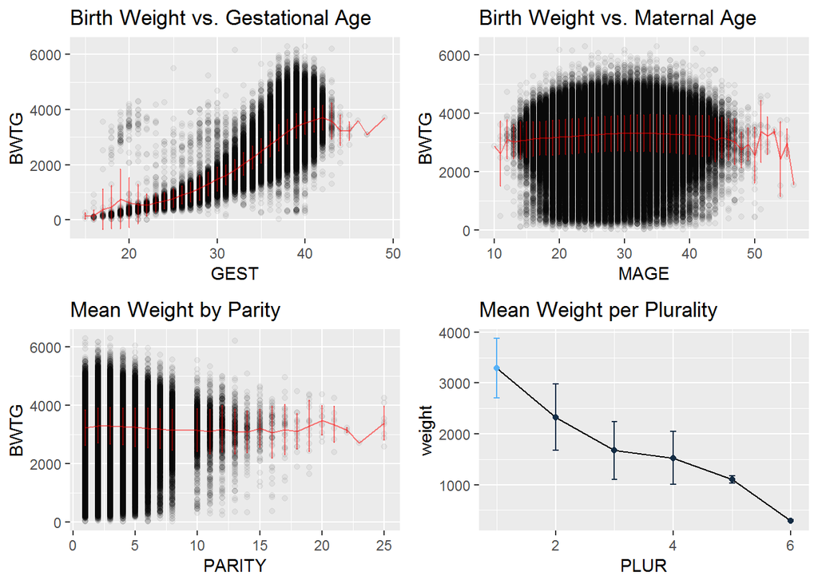

We note that gestational age has a decent amount of curvature which might be helped with a quadratic term. This however would affect interpretability.

Maternal age seems to have little effect outside of the tails (e.g. greater than 45 years of age). Introduction of a nonlinearity would appear helpful here. Parity on birth weight seems to have a small effect. Plurality has a very pronounced effect.

We now inspect the relationship of weight with race, hispanic status, year of birth and county.

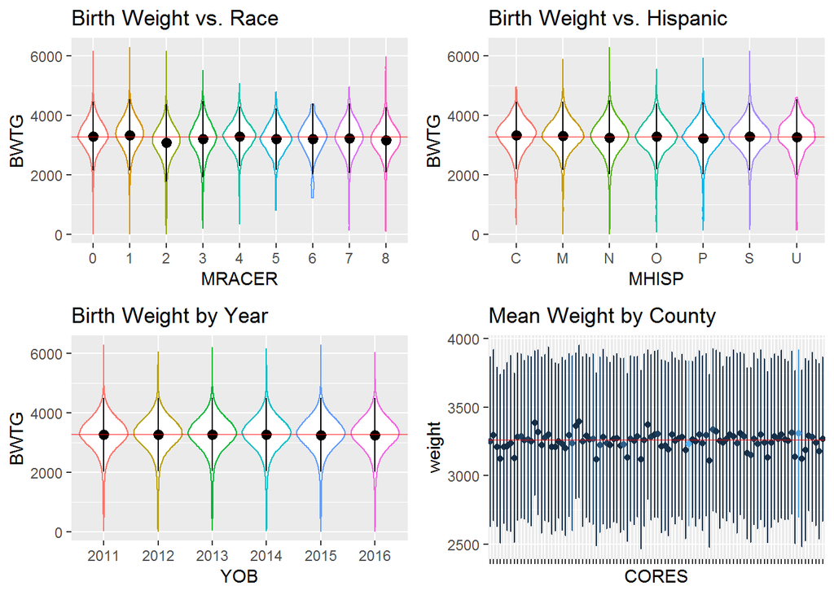

Note the horizontal bar plotted is the average birthweight.

Inspecting race, certain race covariates appear to deviate signficantly from the mean, suggesting that this is a covariate of interest. Reading trough the literature, it appears that in another study of gestational variation published in the International Journal of Epidemiology entitled “Does gestation vary by ethnic group? A London-based study of over 122,000 pregnancies with spontaneous onset of labour” (https://academic.oup.com/ije/article/33/1/107/668109) categorization of european, african, and asian ancestry suffices.

| MRACER | 0 | 1 | 2 | 3 | 4 | 5 | 6 | 7 | 8 |
| --- | --- | --- | --- | --- | --- | --- | --- | --- | --- |
| Freq | 83225 | 415716 | 172250 | 9991 | 3326 | 575 | 92 | 2108 | 23086 |

With this as prior knowledge, we’ll consider grouping together all of the racial categories of asian ancestry to simplify interpreation.

Due to their small size, the granular subsets of hispanic ethnicity may not be very informative. Investigating the covariate directly, we note the majority reported as not hispanic.

| MHISP | C | M | N | O | P | S | U |
| --- | --- | --- | --- | --- | --- | --- | --- |
| Freq | 1576 | 63647 | 603574 | 6367 | 8140 | 26717 | 348 |

As such, we will consider a transformation to turn hispanic ethnicity into a binary covariate.

Certain counties appear to have significant deviation from the mean. Since county is a proxy for socioeconomic status, it would be worthwhile to link counties through census data to useful socioeconomic indicator such as median income. This would reduce the number of covariates significantly. This would require the addition of another dataset to our analysis, so for the purpose of this study we will choose to ignore the CORES variable.

Inspecting year of bith more closely, we see little variation in any of the covariates year over year.

| YOB | GEST | BWTG | SMOKER | SEX | MAGE | PLUR | PARITY | ASIAN | BLACK | WHITE | OTHER | HISP |
| --- | --- | --- | --- | --- | --- | --- | --- | --- | --- | --- | --- | --- |
| 2011 | 38.5±2.29 | 3259.75±617.95 | 0.14 | 0.51 | 27.4±6 | 1±0.2 | 2.4±1.6 | 0.04 | 0.24 | 0.59 | 0.14 | 0.152 |
| 2012 | 38.51±2.26 | 3263.33±614.49 | 0.14 | 0.51 | 27.5±6 | 1±0.2 | 2.4±1.6 | 0.04 | 0.24 | 0.58 | 0.14 | 0.150 |
| 2013 | 38.52±2.31 | 3264.36±617.39 | 0.14 | 0.51 | 27.7±5.9 | 1±0.2 | 2.4±1.6 | 0.04 | 0.25 | 0.58 | 0.13 | 0.148 |
| 2014 | 38.54±2.27 | 3261.6±614.89 | 0.13 | 0.51 | 27.9±5.9 | 1±0.2 | 2.5±1.6 | 0.04 | 0.24 | 0.59 | 0.13 | 0.147 |
| 2015 | 38.51±2.3 | 3252.78±620.17 | 0.13 | 0.51 | 28.1±5.8 | 1±0.2 | 2.5±1.6 | 0.04 | 0.24 | 0.59 | 0.13 | 0.150 |
| 2016 | 38.48±2.28 | 3252.44±619.23 | 0.12 | 0.51 | 28.3±5.8 | 1±0.2 | 2.5±1.6 | 0.05 | 0.24 | 0.59 | 0.13 | 0.152 |

As such, we believe that there is not a significant time-related trend and that year of birth is potentially not a covariate of interest.

We now inspect the smoking variables.

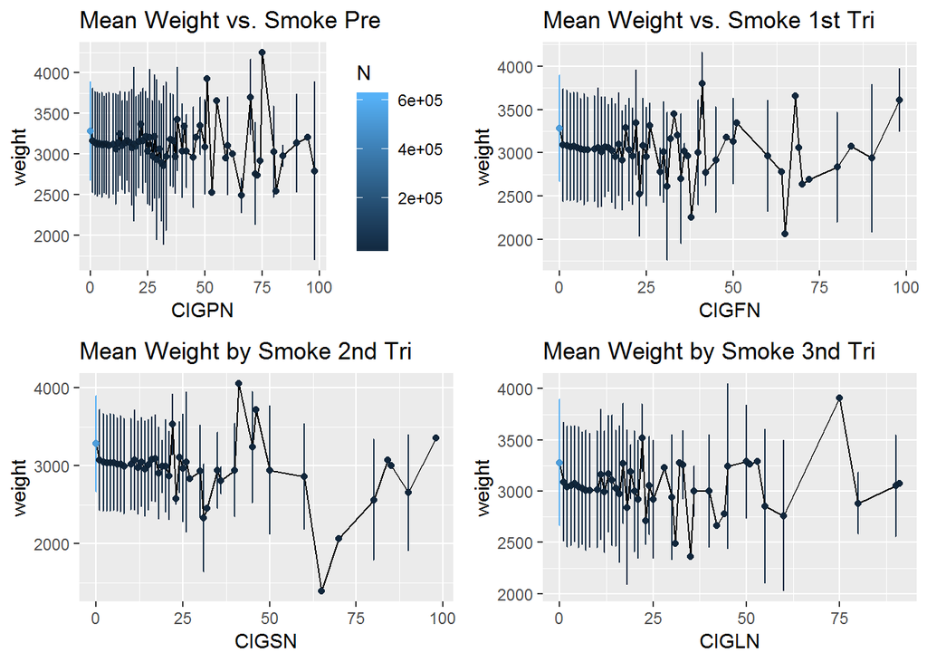

Note in most cases we observe an initial drop from zero followed by wild fluctuations as the number of cigarettes smoked per day increases. The vast majority of mothers are non smokers throughout each phase of pregnancy.

- 86.8% of women don’t smoke before pregancy.
- 90.5% of women don’t smoke during the first trimester.
- 92% of women don’t smoke during the second trimester.
- 92.4% of women don’t smoke during the last trimester.

In addition, a correlation matrix revealed heavy correlations between all of the smoking variables.

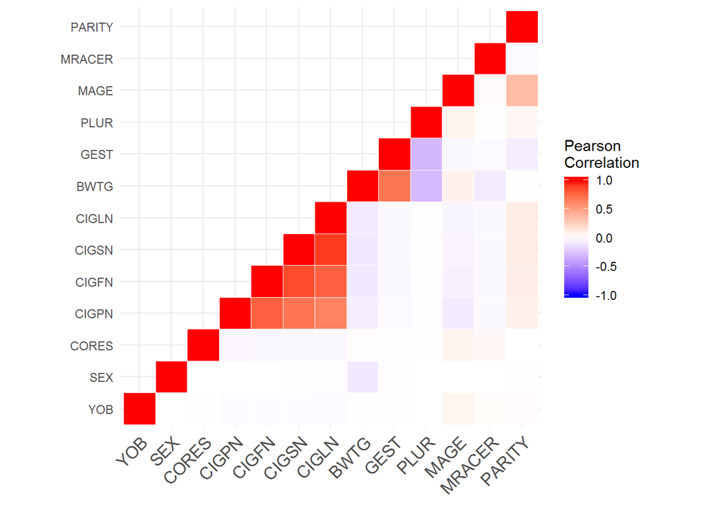

This lead us to beleive that binarizing each of the smoking covariates or combining them into a single covariate would make sense.

## Model Selection

Based on the exploratory data analysis we devised the following suite of models to train and evaluate:

With 5-fold cross validation, we see the following results for all of the models tested:

| name | formula | rsquared | rmse |
| --- | --- | --- | --- |
| bsmokes_bpar | BWTG ~ SEX + CIGPNBIN + CIGFNBIN + CIGSNBIN + CIGLNBIN + GEST + PLUR + MAGE + MRACER + MHISP + PARITYBIN | 0.5284 | 423.98 |
| bsmokes_bpar_bhisp | BWTG ~ SEX + CIGPNBIN + CIGFNBIN + CIGSNBIN + CIGLNBIN + GEST + PLUR + MAGE + MRACER + HISP + PARITYBIN | 0.5284 | 424.00 |
| bsmokes_bpar_crace_bhisp | BWTG ~ SEX + CIGPNBIN + CIGFNBIN + CIGSNBIN + CIGLNBIN + GEST + PLUR + MAGE + RACE + HISP + PARITYBIN | 0.5282 | 424.05 |
| bsmokes_bpar_crace_dhisp | BWTG ~ SEX + CIGPNBIN + CIGFNBIN + CIGSNBIN + CIGLNBIN + GEST + PLUR + MAGE + RACE + PARITYBIN | 0.5282 | 424.07 |
| bsmokes_bpar_crace_dhisp_gest2 | BWTG ~ SEX + CIGPNBIN + CIGFNBIN + CIGSNBIN + CIGLNBIN + GEST^2 + PLUR + MAGE + RACE + PARITYBIN | 0.5282 | 424.07 |
| bsmokes_bpar_crace_dhisp_mage2 | BWTG ~ SEX + CIGPNBIN + CIGFNBIN + CIGSNBIN + CIGLNBIN + GEST + PLUR + MAGE^2 + RACE + PARITYBIN | 0.5282 | 424.07 |
| bsmokes | BWTG ~ SEX + CIGPNBIN + CIGFNBIN + CIGSNBIN + CIGLNBIN + GEST + PLUR + MAGE + MRACER + MHISP + PARITY | 0.5254 | 425.34 |
| full | BWTG ~ YOB + SEX + CORES + CIGPN + CIGSN + CIGLN + GEST + PLUR + MAGE + MRACER + MHISP + PARITY | 0.5248 | 425.70 |
| simple | BWTG ~ SEX + SMOKER + GEST + PLUR + MAGE + RACE + HISP + PARITYBIN | 0.5244 | 425.78 |
| dyob_dcores | BWTG ~ SEX + CIGPN + CIGFN + CIGSN + CIGLN + GEST + PLUR + MAGE + MRACER + MHISP + PARITY | 0.5236 | 426.13 |
| bsmoke | BWTG ~ SEX + SMOKER + GEST + PLUR + MAGE + MRACER + MHISP + PARITY | 0.5216 | 427.03 |
| bsmokes_log | log(BWTG) ~ SEX + CIGPNBIN + CIGFNBIN + CIGSNBIN + CIGLNBIN + GEST + PLUR + MAGE + MRACER + MHISP + PARITY | 0.6497 | 446.92 |
| full_log | log(BWTG) ~ YOB + SEX + CORES + CIGPN + CIGSN + CIGLN + GEST + PLUR + MAGE + MRACER + MHISP + PARITY | 0.6497 | 447.07 |
| dyob_dcores_log | log(BWTG) ~ SEX + CIGPN + CIGFN + CIGSN + CIGLN + GEST + PLUR + MAGE + MRACER + MHISP + PARITY | 0.6488 | 447.58 |
| bsmoke_log | log(BWTG) ~ SEX + SMOKER + GEST + PLUR + MAGE + MRACER + MHISP + PARITY | 0.6480 | 448.36 |
| simple_log | log(BWTG) ~ SEX + SMOKER + GEST + PLUR + MAGE + RACE + HISP + PARITY | 0.6479 | 448.44 |

Investigating the models above, we see that log transforming the outcome improves fit greatly, however this is clearly a result of overfitting as the RMS errors are the highest for those transformations. Binarization increased performance broadly. Introducing quadratic terms did nothing. Of the models with the lowest RMSE (within 0.1 from the smallest), we see that the model which binarizes the smoking variables, combines the races as mentioned prior, and drops the hispanic term (bsmokes_bpar_crace_dhisp) performs extremely well when compared against the other models of similar performance. In our view, this model has the optimal blend of simplicity, interpretability and performance.

Now that we have selected our covariates, we’ll build our final OLS model and compare it against a robust regression.

## Model Evaluation

```
##
## Call:
## lm(formula = BWTG ~ SEX + CIGPNBIN + CIGFNBIN + CIGSNBIN + CIGLNBIN +
##     GEST + PLUR + MAGE + RACE + PARITYBIN, data = birth_data[1:10000,
##     ])
##
## Residuals:
##     Min      1Q  Median      3Q     Max
## -2242.2  -275.3   -16.2   250.6  3336.5
##
## Coefficients:
##               Estimate Std. Error t value Pr(>|t|)
## (Intercept) -3318.3412    87.9367 -37.736  < 2e-16 ***
## SEX2         -118.7553     8.4603 -14.037  < 2e-16 ***
## CIGPNBIN1      27.9580    22.6237   1.236   0.2166
## CIGFNBIN1     -48.5579    35.2077  -1.379   0.1679
## CIGSNBIN1     -86.1877    49.7106  -1.734   0.0830 .
## CIGLNBIN1    -128.4726    44.8715  -2.863   0.0042 **
## GEST          177.5843     1.9525  90.950  < 2e-16 ***
## PLUR         -320.0852    22.5724 -14.180  < 2e-16 ***
## MAGE            6.0187     0.7647   7.871 3.89e-15 ***
## RACEA        -156.1555    23.4018  -6.673 2.64e-11 ***
## RACEB        -193.4372    10.5006 -18.422  < 2e-16 ***
## RACEO         -59.6316    12.8184  -4.652 3.33e-06 ***
## PARITYBIN1     87.6151     9.4449   9.276  < 2e-16 ***
## ---
## Signif. codes:  0 '***' 0.001 '**' 0.01 '*' 0.05 '.' 0.1 ' ' 1
##
## Residual standard error: 422.4 on 9987 degrees of freedom
## Multiple R-squared:  0.5292, Adjusted R-squared:  0.5286
## F-statistic: 935.5 on 12 and 9987 DF,  p-value: < 2.2e-16
```

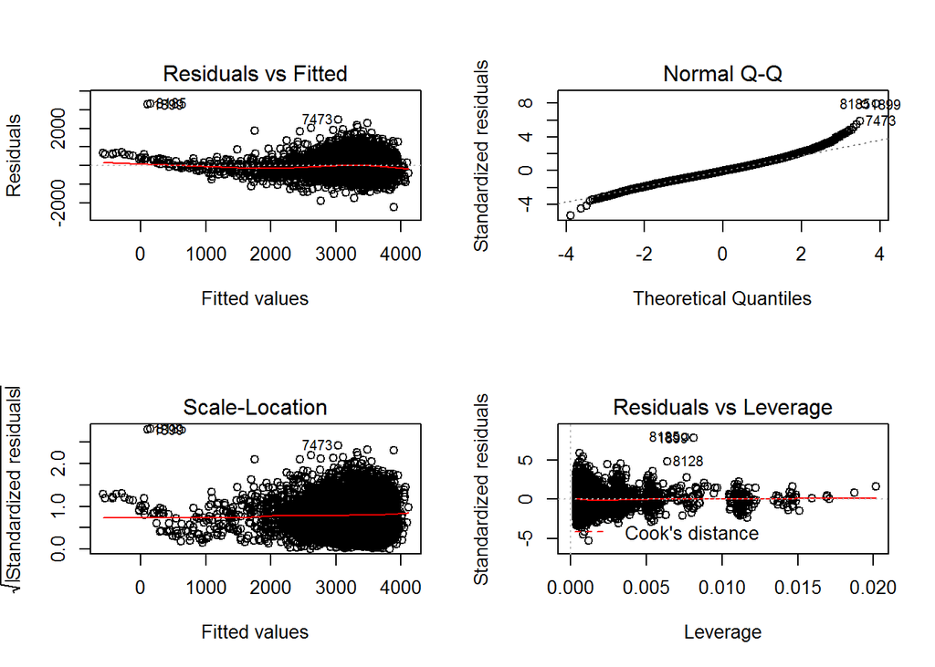

```
##
## Call: rlm(formula = BWTG ~ SEX + CIGPNBIN + CIGFNBIN + CIGSNBIN + CIGLNBIN +
##     GEST + PLUR + MAGE + RACE + PARITYBIN, data = birth_data[1:10000,
##     ])
## Residuals:
##       Min        1Q    Median        3Q       Max
## -2230.832  -262.622    -4.695   262.047  3394.791
##
## Coefficients:
##             Value      Std. Error t value
## (Intercept) -3427.8207    84.9802   -40.3367
## SEX2         -118.9389     8.1759   -14.5476
## CIGPNBIN1       6.7729    21.8631     0.3098
## CIGFNBIN1     -38.9921    34.0240    -1.1460
## CIGSNBIN1     -57.5111    48.0393    -1.1972
## CIGLNBIN1    -142.2636    43.3629    -3.2808
## GEST          180.0636     1.8869    95.4285
## PLUR         -310.4137    21.8135   -14.2304
## MAGE            5.7647     0.7390     7.8008
## RACEA        -154.6130    22.6150    -6.8368
## RACEB        -195.2216    10.1476   -19.2383
## RACEO         -66.7562    12.3875    -5.3890
## PARITYBIN1     90.6850     9.1274     9.9355
##
## Residual standard error: 389.1 on 9987 degrees of freedom
```

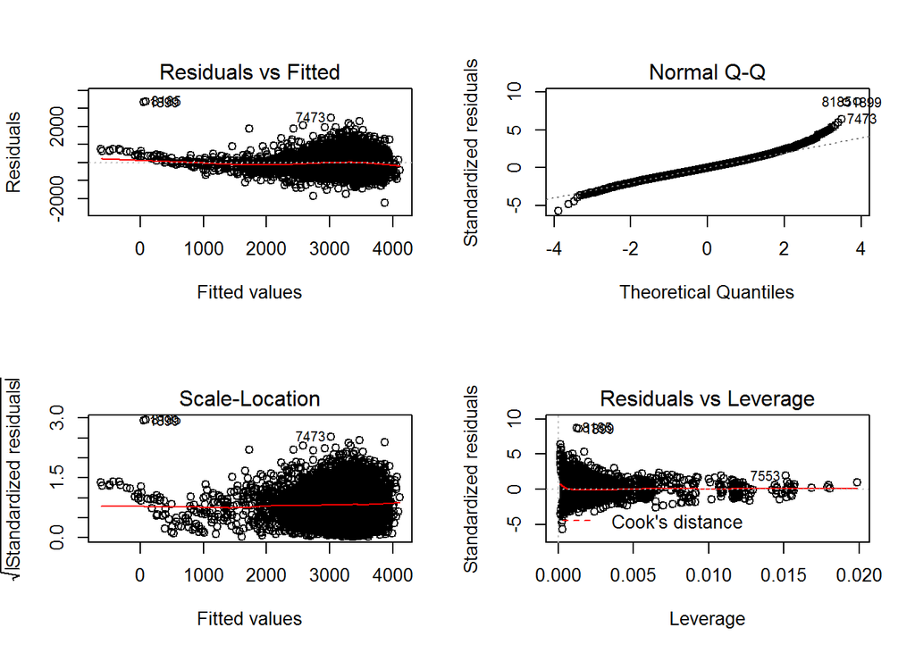

In analyzing the robust regression, we see little improvement. Furthermore, we see little change in the effect sizes of the covariates. As such, we choose our OLS model for reporting.

## Quantile Regression

### Full Model Based on OLS

```
##
## Call: rq(formula = BWTG ~ SEX + CIGPNBIN + CIGFNBIN + CIGSNBIN + CIGLNBIN +
##     GEST + PLUR + MAGE + RACE + PARITYBIN, tau = c(0.05, 0.25,
##     0.5, 0.75, 0.95), data = birth_data[1:10000, ])
##
## tau: [1] 0.05
##
## Coefficients:
##             Value       Std. Error  t value     Pr(>|t|)
## (Intercept) -4156.02000    73.07979   -56.86962     0.00000
## SEX2          -96.36000    13.81465    -6.97520     0.00000
## CIGPNBIN1     -14.48000    31.97574    -0.45284     0.65067
## CIGFNBIN1    -174.08000    51.90478    -3.35383     0.00080
## CIGSNBIN1     -86.52000    50.22997    -1.72248     0.08501
## CIGLNBIN1      35.44000    30.58816     1.15862     0.24664
## GEST          181.48000     1.51515   119.77700     0.00000
## PLUR         -178.46000    18.65673    -9.56545     0.00000
## MAGE            1.64000     1.23110     1.33214     0.18285
## RACEA        -204.84000    30.24658    -6.77234     0.00000
## RACEB        -192.36000    16.77048   -11.47016     0.00000
## RACEO         -31.20000    16.66873    -1.87177     0.06127
## PARITYBIN1     96.20000    14.41929     6.67162     0.00000
##
## Call: rq(formula = BWTG ~ SEX + CIGPNBIN + CIGFNBIN + CIGSNBIN + CIGLNBIN +
##     GEST + PLUR + MAGE + RACE + PARITYBIN, tau = c(0.05, 0.25,
##     0.5, 0.75, 0.95), data = birth_data[1:10000, ])
##
## tau: [1] 0.25
##
## Coefficients:
##             Value       Std. Error  t value     Pr(>|t|)
## (Intercept) -3667.59024   114.81710   -31.94289     0.00000
## SEX2         -122.84878     9.88130   -12.43246     0.00000
## CIGPNBIN1      -0.85854    22.76613    -0.03771     0.96992
## CIGFNBIN1     -19.84390    32.12064    -0.61779     0.53673
## CIGSNBIN1    -137.56585    46.96080    -2.92938     0.00340
## CIGLNBIN1     -70.93659    38.27428    -1.85337     0.06386
## GEST          179.29268     2.60592    68.80216     0.00000
## PLUR         -262.49268    23.49830   -11.17071     0.00000
## MAGE            4.01951     0.91984     4.36980     0.00001
```

[output cut: 55 more lines]

```
## Coefficients:
##             Value       Std. Error  t value     Pr(>|t|)
## (Intercept) -2355.50000   296.99999    -7.93098     0.00000
## SEX2         -157.00000    19.74867    -7.94990     0.00000
## CIGPNBIN1     133.50000    95.19060     1.40245     0.16081
## CIGFNBIN1     -48.78571   153.62060    -0.31757     0.75082
## CIGSNBIN1    -230.21429   148.76248    -1.54753     0.12177
## CIGLNBIN1     -84.42857    57.99684    -1.45574     0.14549
## GEST          172.50000     6.91861    24.93274     0.00000
## PLUR         -474.71429    32.06702   -14.80382     0.00000
## MAGE           11.07143     1.86152     5.94751     0.00000
## RACEA        -153.28571    41.45867    -3.69731     0.00022
## RACEB        -199.00000    25.84879    -7.69862     0.00000
## RACEO         -68.85714    30.66136    -2.24573     0.02474
## PARITYBIN1     55.71429    23.79838     2.34110     0.01925
```

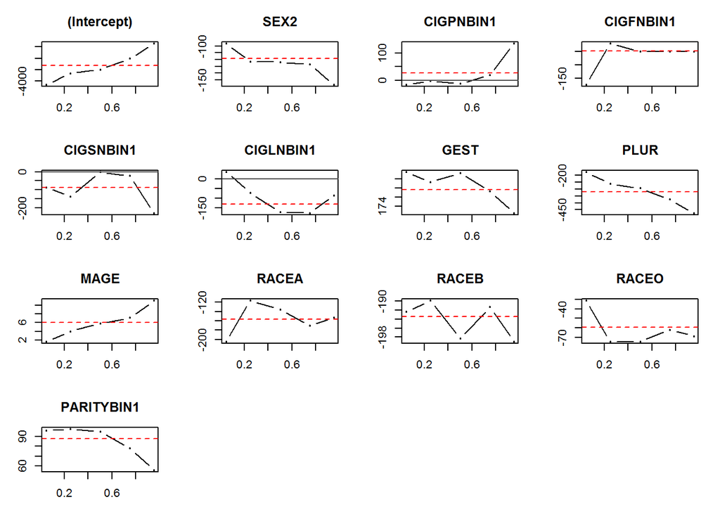

### Model Without Smoking Status

```
##
## Call: rq(formula = BWTG ~ SEX + GEST + PLUR + MAGE + RACE + PARITYBIN,
##     tau = c(0.05, 0.25, 0.5, 0.75, 0.95), data = birth_data[1:10000,
##         ])
##
## tau: [1] 0.05
##
## Coefficients:
##             Value       Std. Error  t value     Pr(>|t|)
## (Intercept) -4262.85470    81.04267   -52.60013     0.00000
## SEX2          -90.60684    15.93890    -5.68463     0.00000
## GEST          181.82051     1.31986   137.75777     0.00000
## PLUR         -173.15385    34.19397    -5.06387     0.00000
## MAGE            3.40171     1.39735     2.43439     0.01493
## RACEA        -151.78632    58.77547    -2.58248     0.00982
## RACEB        -150.25641    20.57491    -7.30289     0.00000
## RACEO          20.00000    18.28845     1.09359     0.27416
## PARITYBIN1     70.36752    17.45838     4.03059     0.00006
##
## Call: rq(formula = BWTG ~ SEX + GEST + PLUR + MAGE + RACE + PARITYBIN,
##     tau = c(0.05, 0.25, 0.5, 0.75, 0.95), data = birth_data[1:10000,
##         ])
##
## tau: [1] 0.25
##
## Coefficients:
##             Value       Std. Error  t value     Pr(>|t|)
## (Intercept) -3802.06373   107.57258   -35.34417     0.00000
## SEX2         -115.26961     9.95819   -11.57535     0.00000
## GEST          180.94608     2.47615    73.07549     0.00000
## PLUR         -260.09804    16.50694   -15.75689     0.00000
## MAGE            5.60294     0.89729     6.24426     0.00000
## RACEA         -94.27451    25.35910    -3.71758     0.00020
## RACEB        -165.64216    12.16482   -13.61649     0.00000
## RACEO         -44.49510    15.59582    -2.85301     0.00434
## PARITYBIN1     74.76471    10.69436     6.99104     0.00000
##
## Call: rq(formula = BWTG ~ SEX + GEST + PLUR + MAGE + RACE + PARITYBIN,
##     tau = c(0.05, 0.25, 0.5, 0.75, 0.95), data = birth_data[1:10000,
##         ])
```

[output cut: 35 more lines]

```
##         ])
##
## tau: [1] 0.95
##
## Coefficients:
##             Value       Std. Error  t value     Pr(>|t|)
## (Intercept) -2504.25455   303.13307    -8.26124     0.00000
## SEX2         -155.25455    21.15350    -7.33943     0.00000
## GEST          174.30909     7.04425    24.74488     0.00000
## PLUR         -468.45455    46.24541   -10.12975     0.00000
## MAGE           13.54545     1.97344     6.86388     0.00000
## RACEA        -150.61818    28.05936    -5.36784     0.00000
## RACEB        -194.69091    27.02363    -7.20447     0.00000
## RACEO         -61.01818    32.40169    -1.88318     0.05971
## PARITYBIN1     44.07273    23.98733     1.83733     0.06619
```

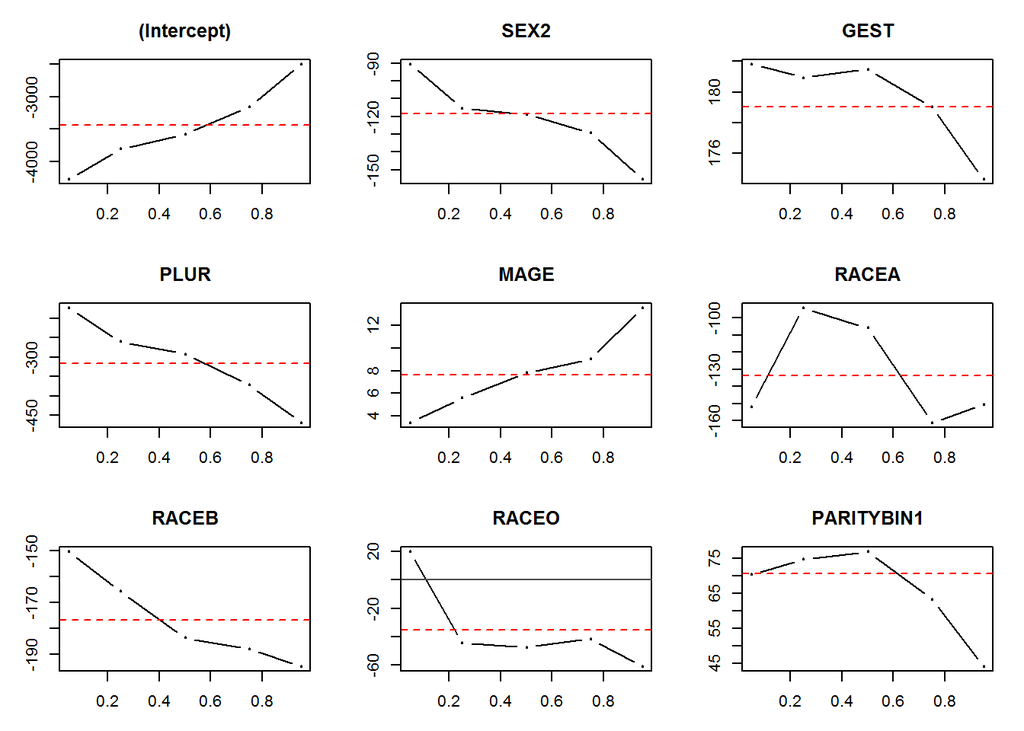

### Model With Smoking Binary

```
##
## Call: rq(formula = BWTG ~ SEX + SMOKER + GEST + PLUR + MAGE + RACE +
##     PARITYBIN, tau = c(0.05, 0.25, 0.5, 0.75, 0.95), data = birth_data[1:10000,
##     ])
##
## tau: [1] 0.05
##
## Coefficients:
##             Value       Std. Error  t value     Pr(>|t|)
## (Intercept) -4134.11715    73.21004   -56.46926     0.00000
## SEX2          -98.95397    14.16902    -6.98383     0.00000
## SMOKERTRUE   -186.87866    19.29285    -9.68642     0.00000
## GEST          181.39331     1.14872   157.90888     0.00000
## PLUR         -204.59833    42.44982    -4.81977     0.00000
## MAGE            1.94979     1.27251     1.53224     0.12549
## RACEA        -202.78243    37.59549    -5.39380     0.00000
## RACEB        -191.38912    17.58625   -10.88288     0.00000
## RACEO         -32.14644    16.14203    -1.99147     0.04646
## PARITYBIN1     96.48536    14.67089     6.57665     0.00000
##
## Call: rq(formula = BWTG ~ SEX + SMOKER + GEST + PLUR + MAGE + RACE +
##     PARITYBIN, tau = c(0.05, 0.25, 0.5, 0.75, 0.95), data = birth_data[1:10000,
##     ])
##
## tau: [1] 0.25
##
## Coefficients:
##             Value       Std. Error  t value     Pr(>|t|)
## (Intercept) -3693.55357   114.57609   -32.23669     0.00000
## SEX2         -119.60714    10.33008   -11.57853     0.00000
## SMOKERTRUE   -149.69643    16.27907    -9.19564     0.00000
## GEST          179.69643     2.57446    69.79966     0.00000
## PLUR         -262.32143    27.07850    -9.68744     0.00000
## MAGE            4.41071     0.95743     4.60680     0.00000
## RACEA        -115.44643    27.09146    -4.26136     0.00002
## RACEB        -179.12500    12.51974   -14.30741     0.00000
## RACEO         -75.73214    14.99194    -5.05152     0.00000
## PARITYBIN1     89.50000    11.21669     7.97918     0.00000
##
## Call: rq(formula = BWTG ~ SEX + SMOKER + GEST + PLUR + MAGE + RACE +
```

[output cut: 40 more lines]

```
##
## tau: [1] 0.95
##
## Coefficients:
##             Value       Std. Error  t value     Pr(>|t|)
## (Intercept) -2352.00000   291.10816    -8.07947     0.00000
## SEX2         -154.40000    20.49737    -7.53267     0.00000
## SMOKERTRUE    -78.80000    35.35902    -2.22857     0.02586
## GEST          171.60000     6.76829    25.35354     0.00000
## PLUR         -486.40000    41.48890   -11.72362     0.00000
## MAGE           13.00000     1.92934     6.73807     0.00000
## RACEA        -164.00000    27.08629    -6.05472     0.00000
## RACEB        -194.20000    25.72546    -7.54894     0.00000
## RACEO         -70.60000    33.14472    -2.13005     0.03319
## PARITYBIN1     36.40000    22.64729     1.60726     0.10803
```

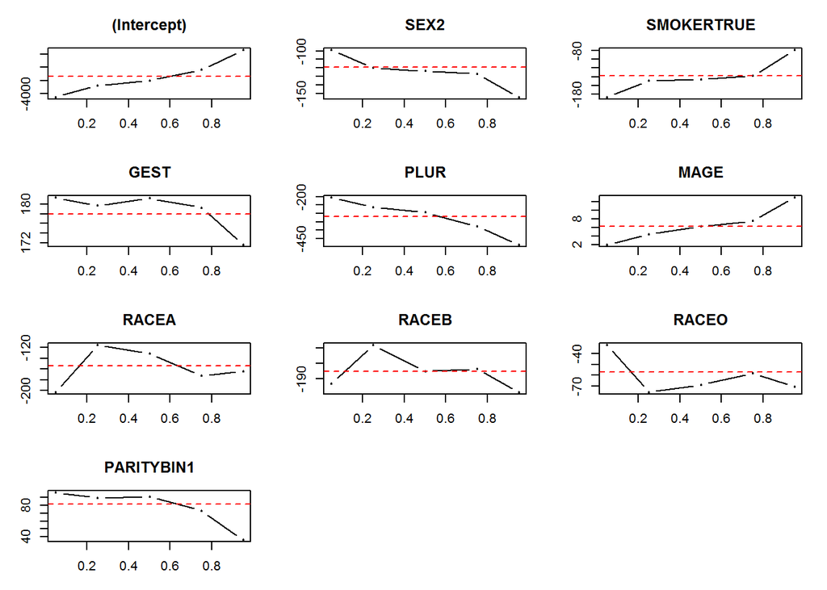